# DAB_501-Assignment 1

## Task_1 :

Identify 3 datasets as candidates for Project #1 and for each provide a brief description, including variables and variable types.  
(24 marks)

# Dataset-1

### Context:

Few key insights like if any particular race is being ill treated or the mindset and general weapon used by criminal can be derived using the dataset.

```r
library("readxl",warn.conflicts = FALSE)
x<-read_excel("E:\\St.Clair\\Basic Stats\\Assignments\\shootings.xlsx")
x
```

| id | name | date | armed | age | race | city | signs_of_mental_illness | threat_level | body_camera | arms_category |
| --- | --- | --- | --- | --- | --- | --- | --- | --- | --- | --- |
| 3 | Tim Elliot | 2015-01-02 | gun | 53.00000 | Asian | Shelton | TRUE | attack | FALSE | Guns |
| 4 | Lewis Lee Lembke | 2015-01-02 | gun | 47.00000 | White | Aloha | FALSE | attack | FALSE | Guns |
| 5 | John Paul Quintero | 2015-01-03 | unarmed | 23.00000 | Hispanic | Wichita | FALSE | other | FALSE | Unarmed |
| 8 | Matthew Hoffman | 2015-01-04 | toy weapon | 32.00000 | White | San Francisco | TRUE | attack | FALSE | Other unusual objects |
| 9 | Michael Rodriguez | 2015-01-04 | nail gun | 39.00000 | Hispanic | Evans | FALSE | attack | FALSE | Piercing objects |
| 11 | Kenneth Joe Brown | 2015-01-04 | gun | 18.00000 | White | Guthrie | FALSE | attack | FALSE | Guns |
| 13 | Kenneth Arnold Buck | 2015-01-05 | gun | 22.00000 | Hispanic | Chandler | FALSE | attack | FALSE | Guns |
| 15 | Brock Nichols | 2015-01-06 | gun | 35.00000 | White | Assaria | FALSE | attack | FALSE | Guns |
| 16 | Autumn Steele | 2015-01-06 | unarmed | 34.00000 | White | Burlington | FALSE | other | TRUE | Unarmed |
| 17 | Leslie Sapp III | 2015-01-06 | toy weapon | 47.00000 | Black | Knoxville | FALSE | attack | FALSE | Other unusual objects |

[output cut: 990 more lines]

```r
colnames(x)
```

```
 [1] "id"                      "name"                    "date"
 [4] "armed"                   "age"                     "race"
 [7] "city"                    "signs_of_mental_illness" "threat_level"
[10] "body_camera"             "arms_category"
```

# Dataset-2

### Context:

The below dataset is part of a larger set. This gives the information about the cars which were kept on sale in craigslist which is one of the largest collection of used cars. It consist of all the major details like the car model, the year of manufacturing, number of kilometers the car has been driven and all.

Using this dataset one can analize and conclude the most profitable choice in order to get a own vehicle.

```r
library("readxl",warn.conflicts = FALSE)
y<-read_excel("E:\\St.Clair\\Basic Stats\\Assignments\\Used-Cars.xlsx")
y
```

| Name | Location | Year | Kilometers_Driven | Fuel_Type | Transmission | Mileage | Engine | Power | Seats |
| --- | --- | --- | --- | --- | --- | --- | --- | --- | --- |
| Maruti Alto K10 LXI CNG | Delhi | 2014 | 40929 | CNG | Manual | 32.26 km/kg | 998 CC | 58.2 bhp | 4 |
| Maruti Alto 800 2016-2019 LXI | Coimbatore | 2013 | 54493 | Petrol | Manual | 24.7 kmpl | 796 CC | 47.3 bhp | 5 |
| Toyota Innova Crysta Touring Sport 2.4 MT | Mumbai | 2017 | 34000 | Diesel | Manual | 13.68 kmpl | 2393 CC | 147.8 bhp | 7 |
| Toyota Etios Liva GD | Hyderabad | 2012 | 139000 | Diesel | Manual | 23.59 kmpl | 1364 CC | null bhp | 5 |
| Hyundai i20 Magna | Mumbai | 2014 | 29000 | Petrol | Manual | 18.5 kmpl | 1197 CC | 82.85 bhp | 5 |
| Mahindra XUV500 W8 2WD | Coimbatore | 2016 | 85609 | Diesel | Manual | 16.0 kmpl | 2179 CC | 140 bhp | 7 |
| Toyota Fortuner 4x2 AT TRD Sportivo | Pune | 2015 | 59000 | Diesel | Automatic | 12.55 kmpl | 2982 CC | 168.7 bhp | 7 |
| Hyundai EON Era Plus | Jaipur | 2013 | 65000 | Petrol | Manual | 21.1 kmpl | 814 CC | 55.2 bhp | 5 |
| Honda City 1.5 S MT | Mumbai | 2011 | 66000 | Petrol | Manual | 17.0 kmpl | 1497 CC | 118 bhp | 5 |
| Mahindra XUV500 W6 2WD | Coimbatore | 2015 | 54684 | Diesel | Manual | 15.1 kmpl | 2179 CC | 140 bhp | 7 |

[output cut: 990 more lines]

```r
colnames(y)
```

```
 [1] "Name"              "Location"          "Year"              "Kilometers_Driven"
 [5] "Fuel_Type"         "Transmission"      "Mileage"           "Engine"
 [9] "Power"             "Seats"
```

### **The Columns:**

1.) **Name**(Format - Character) - This column gives the name of the car that is for sale.  
2.) **Location**(Format - Character) - This column gives the name of the city in which car is available sale.  
3.) **Year**(Format - Double) - This column gives the year from which car is functional.  
4.) **Kilometers_Driven**(Format - double) - This column gives the number of kilometers driven by the car.  
5.) **Fuel_Type**(Format - Charecter) - This column gives the fule type used in the car.  
6.) **Transmission**(Format - Charecter) - This column gives the gear transmission type of the car.  
7.) **Mileage**(Format - Charecter) - This column gives the information about kilometers driven per liter.  
8.) **Engine**(Format - Charecter) - This column represents the engine displacement of the car.  
9.) **Power**(Format - Charecter) - This columns represents the power of the engive.  
10.)**Seats**(Format - Double) - This column gives the number of seats prsent in the car.

# Dataset-3

```r
library("readxl",warn.conflicts = FALSE)
z<-read_excel("E:\\St.Clair\\Basic Stats\\Assignments\\prog_book.xlsx")
z
```

| Rating | Reviews | Book_title | Description | Number_Of_Pages | Type | Price |
| --- | --- | --- | --- | --- | --- | --- |
| 4.17 | 3829 | The Elements of Style | This style manual offers practical advice on improving writing skills. Throughout, the emphasis is on promoting a plain English style. This little book can help you communicate more effectively by sho… | 105 | Hardcover | 9.323529 |
| 4.01 | 1406 | The Information: A History, a Theory, a Flood | James Gleick, the author of the best sellers Chaos and Genius, now brings us a work just as astonishing and masterly: a revelatory chronicle and meditation that shows how information has become the mo… | 527 | Hardcover | 11.000000 |
| 3.33 | 0 | Responsive Web Design Overview For Beginners | In Responsive Web Design Overview For Beginners, you'll get an overview of what to expect when building a responsive website.\r\n\r\nYou'll learn about all of the following:\r\nResponsive Web Design O… | 50 | Kindle Edition | 11.267647 |
| 3.97 | 1658 | Ghost in the Wires: My Adventures as the World's Most Wanted Hacker | If they were a hall of fame or shame for computer hackers, a Kevin Mitnick plaque would be mounted the near the entrance. While other nerds were fumbling with password possibilities, this adept break-… | 393 | Hardcover | 12.873529 |
| 4.06 | 1325 | How Google Works | Both Eric Schmidt and Jonathan Rosenberg came to Google as seasoned Silicon Valley business executives, but over the course of a decade they came to see the wisdom in Coach John Wooden's observation t… | 305 | Kindle Edition | 13.164706 |
| 3.84 | 117 | The Meme Machine | What is a meme? First coined by Richard Dawkins in 'The Selfish Gene', a meme is any idea, behavior, or skill that can be transferred from one person to another by imitation: stories, fashions, invent… | 288 | Paperback | 14.188235 |
| 4.09 | 5938 | Start with Why: How Great Leaders Inspire Everyone to Take Action | Why do you do what you do?\r\n\r\nWhy are some people and organizations more innovative, more influential, and more profitable than others? Why do some command greater loyalty from customers and emplo… | 256 | Hardcover | 14.232353 |
| 4.15 | 1817 | Algorithms to Live By: The Computer Science of Human Decisions | A fascinating exploration of how insights from computer algorithms can be applied to our everyday lives, helping to solve common decision-making problems and illuminate the workings of the human mind\… | 368 | Hardcover | 14.364706 |
| 3.87 | 2093 | Weapons of Math Destruction: How Big Data Increases Inequality and Threatens Democracy | A former Wall Street quant sounds an alarm on mathematical modelingâ\200”a pervasive new force in society that threatens to undermine democracy and widen inequality.\r\n \r\nWe live in the age of the … | 259 | Hardcover | 14.502941 |
| 4.62 | 0 | ZX Spectrum Games Code Club: Twenty fun games to code and learn | This book is ideal for ZX Spectrum fans and beginner coders of any age that want to learn or practice building simple games. Contains 20 games specifically created for this book, from Arcade classics … | 128 | Paperback | 14.641176 |

[output cut: 261 more lines]

```r
colnames(z)
```

```
[1] "Rating"          "Reviews"         "Book_title"      "Description"     "Number_Of_Pages"
[6] "Type"            "Price"
```

1.)**Rating**(Format - double) - This column gives the rating of the book provided by the user.  
2.)**Reviews**(Format - double) - This column shows the review given by the used to the book.  
3.)**Book_title**(Format - Character) - This column gives the Title of the book.  
4.)**Description**(Format - Character) - This column gives the description of the book.  
5.)**Number_Of_Pages**(Format - double) - This column gives the number if pages present in the book.  
6.)**Type**(Format - Character) - This column gives whether the book is hardcover or paper or kindle.  
7.)**Price**(Format - double) - This column gives the price of the book.

### Task_2

**Find an example of a good data visualization. (10 marks)**  
**Cite the author and/or source of the visualization (provide a link, if applicable)**  
**Provide at least 3 reasons why you consider this to be a good visualization**

Data visualization is the practice of translating information into a visual context, such as a map or graph, to make data easier for the human brain to understand and pull insights from. The main goal of data visualization is to make it easier to identify patterns, trends and outliners in large datasets.

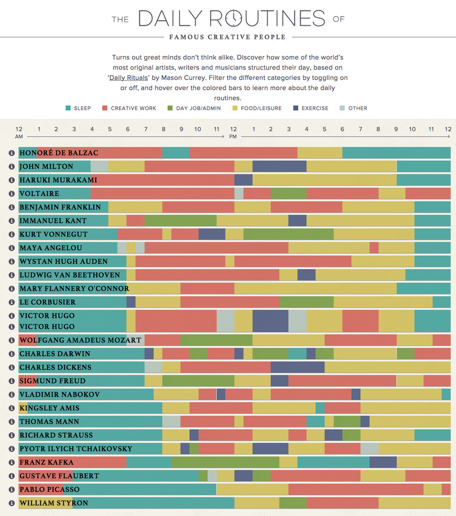

The above visualization depicts the 24 hour schedule of the prominent creative people in the space one schedule have taken.  
I personally believe this is a good visualization because of  
**1.)** More data has been represented using a suitable plot without data overloading.  
**2.)** Proper use of complimentary secondary colors with lesser hue makes this representation eye pleasing.  
**3.)** This chart is onto point simple and easy to uderstand.

### Task_3

**Find an example of a bad data visualization. (10 marks)**  
**Cite the author and/or source of the visualization (provide a link, if applicable)**  
**Provide at least 3 reasons why you consider this to be a bad visualization**

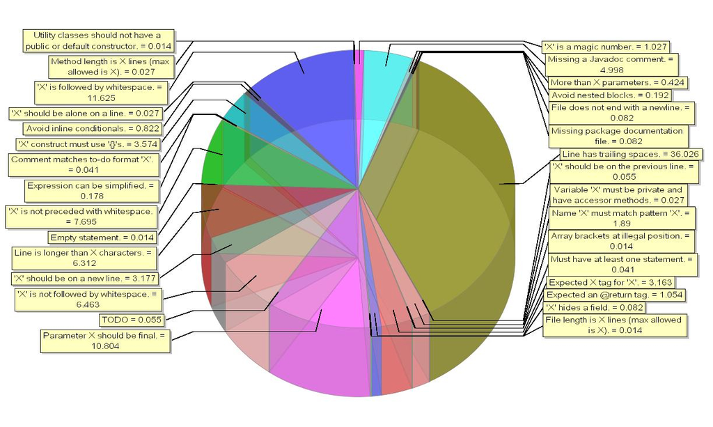

I believe this represents a bad visualization because of the reasons  
**1.)** The plot selected does not properly convey the information visually creating an information overload.  
**2.)** The 3D representation of the pie chart makes it tough to differentiate between the boundaries of pies.  
**3.)** The color selection in transparent plot makes it unpleasant to read data.